# 論文作成に必要なRのスキル

高齢者を対象とした大規模ワクチン調査を使った実習

# 最初に

卒論に必要だと思われるRのコーディングスキルはそれほど難易度的に高くないものも多いが、Rは経済学以外でも使われているため、経済学部の学生が卒論でよく使うコードがまとめられた文献も少ない印象。そこで、昨年度実施した大規模なアンケート調査を実際に解析してみて、卒論執筆までにどのようなコードが書ければ良いのかおさらいしてみよう。調査は2021年8月に約400万円をかけて実施されたweb調査で約3万人を対象に行われた。調査票は別途配っているので確認し、様々な分析を試してみたい。

・vdata1.csv 8月6日から数日間行われた第一回調査。22000人程度

・vdata2.csv 8月20日前後に行われた追加調査。8000人程度

なお、調査はワクチン接種の勧奨が65歳以上に対して優先されていたことに着目し、65歳の前後3歳の方を対象としています。実際の解析は65歳での接種率のジャンプを利用した回帰不連続デザインですが、その他にもワクチンの接種についての有用な情報が含まれていると思いますので、適宜解析すると良いでしょう。

結果の公表は高久先生の許可が必要です。例えば無断でSNSなどに結果をアップするのはやめましょう。

# データの読み込みと確認

データを読み込みます。データの読み込みは読み込みたいファイルが置いてある場所をsetwd()で指定した後に、csvであればread.csvを用いて読み込みます。read.csvはデフォルトで使用できるが、多くのファイルは使用するためにインストールが必要です。インストールするにはinstall.packages(“パッケージ名”)とスクリプトに書いて実行します。インストールしたらlibrary(パッケージ名)で呼び出すと使用できるようになります。インストールは一度すれば後は不要ですが、library(パッケージ名)はその都度必要になります。

例えばエクセルを読み込みたい時にはread_excelを使用します。read_excelはデフォルトで入っていないのでinstall.packages(“readxl”)でインストールが必要になります。

なお、パッケージのインストールはこの資料では#を用いてコメントアウトされますが、使用環境に併せて#を外して実行してください。なお、コメントアウトのショートカットは「Control (or command)+ Shift+ C」です。複数行をコメントアウトしたい場合に便利です。

```r
#install.packages("readxl")
library(readxl)
```

```r
#install.packages("ggplot2") #グラフを作図する時に使うパッケージです
library(ggplot2)
#install.packages("tidyverse")　#パイプ演算子を用いたコーディング全般に必須のパッケージです。
library(tidyverse)

#第1回調査
vdata1 <- read.csv("vdata1.csv") #vdata1という名前のデータフレームとして保存

#第2回調査
vdata2 <- read.csv("vdata2.csv") #vdata2という名前のデータフレームとして保存

vdata <- rbind(vdata1, vdata2) #二つを縦に繋げてvdataというデータフレームとして保存
```

次にvdata1と同じデータをエクセルで読み込んでみましょう。エクセルの場合にはシート名を指定する必要があります。

```r
vdata1 <- read_excel("【ローデータ・GT表】2108_高齢者のワクチン接種調査.xlsx", sheet = "1;group～q34_14")
```

読み込んだらまず、データの先頭行をみてみましょう。変数の数が多すぎるのでここでは10列目までプロットします。指定は[1:10]のように書きます。15列目から55列目までプロット[15:55]です。何行目まで出力するかは、指定しなくてもいいですがn=10と書けば10行目まで出力します。

```r
head(vdata[1:10], n = 10)
```

```
##    no group sc1_1 sc1_2 sc1_3 sc1_4 sc1_5 sc2_1_1 sc2_1_2 sc2_2_1
## 1   1     1     1     1     0     0     0    1955       3    1967
## 2   2     1     1     2     0     0     0    1959       8    1969
## 3   3     1     1     0     1     0     0    1960       2    1960
## 4   4     1     1     0     0     0     0    1954       9    1951
## 5   5     1     1     0     0     0     0    1958       3    1963
## 6   6     1     1     0     0     0     0    1954       8    1952
## 7   7     1     1     1     0     0     0    1954       7    1953
## 8   8     1     1     2     0     0     0    1956       2    1956
## 9   9     1     1     0     0     0     0    1955       8    1957
## 10 10     1     1     3     2     1     0    1958       6    1965
```

```r
head(vdata[15:55], n = 10)
```

```
##    q1_2 q2_1 q2_2 q3_1 q3_2 q5_1 q5_2 q5_3 q6_1_1 q6_1_2 q6_2_1 q6_2_2 q7_1_1_1
## 1    13    6   11   11    5    2    2    2      1      1      1      5        7
## 2     8    7    7   12   13    2    2    2      1      1      2      4        7
## 3    13    4    4    3    3    3    3    3      1      1      1      1        7
## 4    12   NA   NA    3    3    2    2    2      1      1      1      1        6
## 5    12    7    7   11    9    2    2    2      1      1      4      4        8
## 6    13   NA   NA    7    6    2    2    2      1      1      1      1        5
## 7    13    2    3    7   17    1    1    1      1      1      1      1        6
## 8    12    8    7   17   11    2    2    2      1      2      1      6        7
## 9    12    5    5   11    9    1    1    1      1      1      1      2        7
## 10    5    7    7   11   10    1    1    1      1      1      1      1        7
##    q7_1_1_2 q7_1_2_1 q7_1_2_2 q7_2_1_1 q7_2_1_2 q7_2_2_1 q7_2_2_2 q81 q82 q83
## 1        14       NA       NA        8        4       NA       NA  NA  NA  NA
## 2        16        8       10        8       13       NA       NA  NA  NA  NA
## 3        16        7       17        8        6        8        7  NA  NA  NA
```

[output cut: 29 more lines]

なお、以下のようにデータフレームの行と列を指定してデータを表示させることもできます。vdataの8列目の3行目の数字は以下のように表示させられます。行列の指定は使うことも多いので、覚えておくと良いでしょう。

```r
vdata[3,8]
```

```
## [1] 1960
```

8列目のみ最初の10行目まで表示したい場合は以下のように書きます。

```r
vdata[1:10,8]
```

```
##  [1] 1955 1959 1960 1954 1958 1954 1954 1956 1955 1958
```

```r
vdata[3,1:10]
```

```
##   no group sc1_1 sc1_2 sc1_3 sc1_4 sc1_5 sc2_1_1 sc2_1_2 sc2_2_1
## 3  3     1     1     0     1     0     0    1960       2    1960
```

3行目まで、かつ8列目まで抜き出して表示させたければ以下です。

```r
vdata[1:3,1:8]
```

```
##   no group sc1_1 sc1_2 sc1_3 sc1_4 sc1_5 sc2_1_1
## 1  1     1     1     1     0     0     0    1955
## 2  2     1     1     2     0     0     0    1959
## 3  3     1     1     0     1     0     0    1960
```

データフレームにある個別の変数は「dataframe<ドルマーク>varname」で呼び出せます。q10_1（ワクチンの有効性に関する質問）を呼び出したい場合にはdataframeの名前はvdata、変数名はq10_1なのでvdata$q10_1となります。q10_1の先頭の観測値を10個出力した場合には以下のように書きます。

なお、q10_1は「新型コロナウイルスのワクチンの有効性については多くの研究が行われています。１００人がファイザーやモデルナのワクチンを２回接種した場合、そのうち何人が新型コロナウイルス感染症の重症化の危険から守られると思いますか。／人」という質問に対する回答です。正解は95％です。

```r
head(vdata$q10_1, n = 10)
```

```
##  [1] 100  95  95  95  90  90  95  99  90  99
```

q10_1の記述統計量を出力したい場合には以下です。

```r
summary(vdata$q10_1)
```

```
##    Min. 1st Qu.  Median    Mean 3rd Qu.    Max.
##    0.00   80.00   90.00   79.62   95.00  100.00
```

最小値、最大値、中央値、平均、標準偏差などを個別に出力したい場合には、min()、max()、median()、sd()などを用います。

★練習問題

2.q10_1の最小値、最大値、中央値、平均値、標準偏差、四分位範囲、「平方根の平均」を出力してください。四分位範囲はinterquartile rangeで75パーセンタイルと25パーセンタイルの間の領域のことです。IQR()で算出できます。

# 集計

## table, tapply, prop.table

変数を作ったり具体的な解析に入る前に、ささっと集計してデータをみてみたいということは良くあります。属性別の観測値がいくつあるのか知りたい場合はtable、属性別に平均値を集計したい場合にはtapplyが用いられます。特定の属性を持つ人の割合を計算したい場合にはprop.tableが用いられます。この3つを覚えておくと、手もとのデータのおおよその傾向を掴むのに便利です。

職業(q1_1)について各要素の観測値数と、職業別にq10_1の平均値を出力したい場合には以下のように書きます。

```r
table(vdata$q1_1) #各職業の人数を出力
```

```
##
##    1    2    3    4    5    6    7    8    9   11   12   13
## 1938 2703  210 2654 3796  283 4517 3737   42 2250 4249 4513
```

```r
tapply(vdata$q10_1, vdata$q1_1, mean)　#職業別にq10_1の平均値を出力
```

```
##        1        2        3        4        5        6        7        8
## 81.23271 78.05179 74.61905 80.94386 80.21048 81.17668 80.71463 77.52903
##        9       11       12       13
## 79.57143 83.70800 77.53401 79.27786
```

自営業者、専業主婦、無職の方などでワクチンの有効性に関する評価は低いようですね。

次に、コロナ以前の潜在的なワクチンに対する選好を調べるためにq5_1（2019年のインフルワクチンの接種状況）q5_2（2018年のインフルワクチンの接種状況）のクロス集計表を確認してみましょう。

```r
prop.table(table(vdata$q5_1)) #2019年のインフルワクチンの接種状況
```

```
##
##          1          2          3
## 0.45186456 0.52262722 0.02550822
```

```r
prop.table(table(vdata$q5_2)) #2018年のインフルワクチンの接種状況
```

```
##
##          1          2          3
## 0.39165480 0.57432345 0.03402175
```

```r
table(vdata$q5_1,vdata$q5_2) #クロス集計:観測値
```

```
##
##         1     2     3
##   1 11216  2521   222
##   2   851 15201    93
##   3    32    20   736
```

```r
prop.table(table(vdata$q5_1,vdata$q5_2)) #クロス集計:割合
```

```
##
##                1            2            3
##   1 0.3630713453 0.0816068885 0.0071863266
##   2 0.0275475851 0.4920691441 0.0030104882
##   3 0.0010358669 0.0006474168 0.0238249385
```

2年連続で打っている人は36%、2年連続で打っていない人は49%でした。

次にq6_2_1で新型コロナのワクチンの接種状況を確認しましょう。

```r
prop.table(table(vdata$q6_2_1)) #新コロワクチン接種率
```

```
##
##           1           2           3           4           5           6
## 0.667195390 0.164573352 0.003237084 0.061504597 0.093745954 0.005697268
##           7
## 0.004046355
```

新コロワクチンの2回接種率はこのサンプルだと66.7%でした。

★練習問題

1.q9_1とq9_2は1回目と2回目のワクチン接種後の副反応の有無です。副反応のクロス集計表をprop.table()を用いて作成してください。

2.季節性インフルのワクチンを打っていた人は新型コロナワクチンも打ちやすいのでしょうか。クロス集計表を作成して結果について考察してください。prop.tableで割合を計算する際に小数点以下が見にくい場合にはprop.table(table(var1,var2))*100と100倍すると数字が確認しやすくなります。

3.新型コロナワクチンの接種状況別にワクチンの効能に対する主観的評価の平均値を表示させてください。

## 欠損値

データの特性を把握したい場合に欠損値の扱いは覚えておいたほうが良いでしょう。q9_1はワクチン接種後の副反応について聞いていますが、この質問は接種している人しか解答できません。

こうした欠損のある変数の場合には、na.rmという引数にTRUEを設定すると、NAは削除(remove)してから平均が計算されます。

```r
mean(vdata$q9_11)
```

```
## [1] NA
```

```r
mean(vdata$q9_11, na.rm = TRUE) #NAは削除
```

```
## [1] 0.8282225
```

```r
mean(vdata$q9_11, na.rm = FALSE) #NAは削除しない
```

```
## [1] NA
```

欠損のない観測値がいくつあるのか数えるにはどうしたらいいでしょうか？

一般的な方法としてはtable()を使って欠損を除く各要素の観測値数を表示させてその合計をsum()で出力します。q9_11は接種後の患部の痛みがあったかどうか聞いています。この変数について観測値数を出力させてみましょう。

```r
sum(table(vdata$q9_11)) #観測値
```

```
## [1] 25795
```

なお欠損値を含めたサンプルサイズは以下のような方法で算出できます。nrowはコードの名前の通り行の数を数えますが、ベクトルに適用する際にはNROWを用います。

```r
nrow(vdata) #データフレーム全体のサンプルサイズ
```

```
## [1] 30892
```

```r
NROW(vdata$q9_11)　#データフレームの中にあるq9_11のサンプルサイズ
```

```
## [1] 30892
```

★練習問題

q14_1(消毒の頻度)でワクチン接種後の副反応（q9_11は「接種部位の痛み」）の有無が異なるのか出力してください。

なお、欠損がある場合に属性別のサンプルサイズはどう数えたらいいでしょうか？例えば、table(vdata$q14_1)と入力して確認すると、消毒をいつもする人は21662人含まれていますが、その中の何人かはワクチンを打っていないので副反応の解答結果は欠損になっています。

特定のベクトルのどの要素が欠損しているかを判定する関数はis.na()です。 これは名前の通り、欠損している場合にTRUEが返ってくるので、次のようにすることでq9_11が欠損であるサンプルを除外したサブサンプルを作ることができます。

```r
table(vdata$q14_1) #1は「いつも消毒をする人」
```

```
##
##     1     2     3     4
## 21662  8056   784   390
```

```r
no_na <- vdata[!(is.na(vdata$q9_11)), ]
NROW(no_na$q9_11)
```

```
## [1] 25795
```

新しく作成されたデータフレーム（no_na）ではq9_11（接種部位の痛み）の欠損を含まない観測値は25795です。

## サブサンプルでの集計

サンプル全体での傾向と同時にサブサンプルでの集計も頻繁に行うことがあります。ここではざっくりと生年が1957年以前（1956年～1954年）の人はワクチンの優先接種の対象となっており接種率が高い層です。ここでは仮に1956年生まれの女性のサンプルでの結果が知りたいとしましょう。

サブサンプルを作る関数としてsubsetがあります。以下のように用います。

```r
s1956f <- subset(vdata, subset = (sc2_1_1 == 1956 & sc3 == 2))
```

s1956fというサブサンプルができました。後は既に学んだ関数などを用いて集計するだけです。

# パイプ演算子

最近はパイプ%>%を用いてデータの受け渡しを行うのが主流となっています。 パイプはmagrittrパッケージの機能ですが、tidyverseと同時にインストールされています。データ前処理にはdplyr（読み：ディープライアール）というパッケージの関数を主に用います。 dplyrはtidyverseの一部なので、tidyverseがインストールされていればOKです。なお、MACは Control + Shift + m で %>% を出力できます. Windowsは Ctrl + Shift + m で %>% を出力できます（ショートカット）.覚えておくと便利です。

10列目までのデータの先頭行をパイプを用いてみてみましょう

```r
vdata[1:10] %>% head(, n = 10)
```

```
##    no group sc1_1 sc1_2 sc1_3 sc1_4 sc1_5 sc2_1_1 sc2_1_2 sc2_2_1
## 1   1     1     1     1     0     0     0    1955       3    1967
## 2   2     1     1     2     0     0     0    1959       8    1969
## 3   3     1     1     0     1     0     0    1960       2    1960
## 4   4     1     1     0     0     0     0    1954       9    1951
## 5   5     1     1     0     0     0     0    1958       3    1963
## 6   6     1     1     0     0     0     0    1954       8    1952
## 7   7     1     1     1     0     0     0    1954       7    1953
## 8   8     1     1     2     0     0     0    1956       2    1956
## 9   9     1     1     0     0     0     0    1955       8    1957
## 10 10     1     1     3     2     1     0    1958       6    1965
```

この結果は、前のChapterで見たhead()と同じ結果です。 パイプを用いると、パイプの前のオブジェクトをパイプの後の関数の引数としてくれます。

パイプを用いた書き方は以下のとおりです。

・使用するオブジェクトを示す: vdata

・パイプでつなぐ: %>%

・使用する関数を書く: head() mean() table()

別の例を見てみましょう。sc2_1_1は調査対象者の生年、sc2_1_2は生まれ月です。以下の例で確認してください。

```r
#変数の平均を出力
vdata$sc2_1_1 %>% mean()
```

```
## [1] 1956.999
```

パイプを用いないで同じ計算をすると以下のようになります。

```r
mean(vdata$sc2_1_1)
```

```
## [1] 1956.999
```

次に変数の値の分布を出力してみましょう。例えば、今回のデータでは何年生まれの人が何人いるのでしょうか？その場合にはtableという関数を用います。

```r
vdata$sc2_1_1 %>% table()
```

```
## .
## 1954 1955 1956 1957 1958 1959 1960
## 2899 4732 4843 5022 5587 6048 1761
```

```r
vdata$sc2_1_2 %>% table()
```

```
## .
##    1    2    3    4    5    6    7    8    9   10   11   12
## 3414 2719 2876 2408 2325 2170 2476 2619 2456 2513 2434 2482
```

これもパイプを用いないで書くと以下のようになります。

```r
table(vdata$sc2_1_1)
```

```
##
## 1954 1955 1956 1957 1958 1959 1960
## 2899 4732 4843 5022 5587 6048 1761
```

```r
table(vdata$sc2_1_2)
```

```
##
##    1    2    3    4    5    6    7    8    9   10   11   12
## 3414 2719 2876 2408 2325 2170 2476 2619 2456 2513 2434 2482
```

★練習問題

1．パイプを用いて100の平方根を求めてください

2．パイプを用いて調査対象者の生年の中央値を求めてください

# 変数の作成方法

## 2値変数

回答者が女性である場合に１を取る2値変数を作ってみましょう。変数の作成にはmutate()という関数を用います。また2つのカテゴリ（男性or 女性）しかない場合にはif_elase関数を組み合わせて用いると変数が作成できます。sc3 = 2なら女性、１なら男性です。

```r
vdata <- vdata %>% mutate(Fem = if_else(sc3 == 2,1,0))
mean(vdata$Fem)
```

```
## [1] 0.2298006
```

次にワクチンの接種状況に関する変数（1.2回以上接種、2. 1回以上接種）を作成しましょう。本人の接種状況の質問はq6_2_1で回答は以下です。

1 ２回接種した

2 １回接種しており、次の接種の予定も決まっている

3 １回接種したが、次の接種の予定が決まっていない

4 １回も接種していないが、最初の接種の予定は決まっている

5 接種券を受け取ったが１回も接種しておらず、接種の予定も決まっていない

6 １回も接種しておらず、接種の予定も決まっていない

7 あてはまるものはない

```r
#最初に回答の分布を確認しましょう

vdata$q6_2_1 %>% table()
```

```
## .
##     1     2     3     4     5     6     7
## 20611  5084   100  1900  2896   176   125
```

```r
#回答が7の場合には接種状況が不明なのでNAに変換しましょう

vdata <- vdata %>% mutate(q6_2_1_r = ifelse(q6_2_1 == 7,NA,q6_2_1))
vdata$q6_2_1_r %>% table()
```

```
## .
##     1     2     3     4     5     6
## 20611  5084   100  1900  2896   176
```

```r
#2回以上接種
vdata <- vdata %>% mutate(TwoDose = ifelse(q6_2_1_r == 1 ,1,0))
vdata$TwoDose %>% table()
```

```
## .
##     0     1
## 10156 20611
```

```r
#1回以上接種
vdata <- vdata %>% mutate(OneDose = ifelse(q6_2_1_r <= 3,1,0))
vdata$Dose %>% table()
```

```
## < table of extent 0 >
```

次に、大卒以上である場合に１、そうでない場合に０をとる2値変数をCollegeという変数名で、配偶者についてはSCollegeという変数名で作成してみましょう。

学歴の質問はq3_1という変数で以下の定義です

1 中学校／卒業・修了

2 中学校／中退

3 私立高校／卒業・修了

4 私立高校／中退

5 国立・公立高校／卒業・修了

6 国立・公立高校／中退

7 専門学校／卒業・修了

8 専門学校／中退

9 短大・高専／卒業・修了

10 短大・高専／中退

11 私立大学／卒業・修了

12 私立大学／中退

13 国立大学／卒業・修了

14 国立大学／中退

15 公立大学（県立や市立など）／卒業・修了

16 公立大学（県立や市立など）／中退

17 大学院／卒業・修了

18 大学院／中退

```r
vdata <- vdata %>% mutate(College = ifelse(q3_1 == 11 | q3_1 == 13 | q3_1 == 15 | q3_1 >= 17,1,0))
vdata$College %>% mean()
```

```
## [1] 0.569306
```

```r
vdata <- vdata %>% mutate(SCollege = ifelse(q3_2 == 11 | q3_2 == 13 | q3_2 == 15 | q3_2 >= 17,1,0))
vdata$SCollege %>% mean()
```

```
## [1] 0.3232876
```

★練習問題1

q27_1からq27_6は他者への信頼に関する質問です。「あなたの地域の人は機会があればあなたを利用しようとしている」といった意見に対して以下の中から回答を選びます。

1 完全にそう思う

2 そう思う

3 どちらかといえばそう思う

4 どちらともいえない

5 どちらかといえばそう思わない

6 そう思わない

7 全くそう思わない

つまり、他者を信頼する人ほど数字が大きくなるように回答しています。しかしq27_5だけ「あなたの地域の人は基本的には正直だ」という意見で、他者を信頼しない人ほど数字が大きくなるように回答しています。q27_5の質問のみ、1から7の回答を逆にしたあとに、すべの回答を足し合わせて信頼スコア（TrustScore）を作成してください。また信頼スコアが中央値以上である場合に1を取る2値変数を作成してください。

★練習問題2

世帯所得を調査した変数はq25で定義は以下です。「答えたくない」「分からない」という回答を除いて、中位所得以上の世帯が１となるような2値変数（MIncome）を作成してください。

1 世帯の収入はない

2 ５０万円未満

3 ５０万円以上１００万円未満

4 １００万円以上２００万円未満

5 ２００万円以上３００万円未満

6 ３００万円以上４００万円未満

7 ４００万円以上５００万円未満

8 ５００万円以上６００万円未満

9 ６００万円以上７００万円未満

10 ７００万円以上８００万円未満

11 ８００万円以上９００万円未満

12 ９００万円以上１，０００万円未満

13 １，０００万円以上１，２００万円未満

14 １，２００万円以上１，４００万円未満

15 １，４００万円以上１，６００万円未満

16 １，６００万円以上１，８００万円未満

17 １，８００万円以上２，０００万円未満

18 ２，０００万円以上

19 答えたくない

20 分からない

## カテゴリ変数

2つのカテゴリにしたい場合は上記のif_elseが良いですが、3つ以上にしたい場合はcase_whenが便利です。 case_whenはcase_when(条件A ~ 条件が成り立つ場合の値, 条件B ~ 条件が成り立つ場合の値…と書いていきます。

q13_1は「２０２１年６月～現在において、下記の時間は、１日あたり（平均）どれくらいでしたか。／仕事や勉強でのＶＤＴ作業」という質問に対する回答で以下のカテゴリから選びます

1 なし（０時間）

2 １日あたり３０分未満

3 １日あたり３０分程度

4 １日あたり１時間

5 １日あたり２時間

6 １日あたり３時間

7 １日あたり４～５時間

8 １日あたり６～７時間

9 １日あたり８～９時間

10 １日あたり１０～１１時間

11 １日あたり１２時間以上

12 わからない

このままでは解析に使えませんので、分単位でおおよその投入時間を割り当ててみたいと思います。割り当てルールは以下のようにしましょう。

1 0

2 15

3 30

4 60

5 120

6 180

7 270

8 390

9 450

10 630

11 720

12 NA

```r
vdata <- vdata %>% mutate(q13_1_r = case_when(q13_1 == 1 ~ 0,
                                                q13_1 == 2 ~ 15,
                                                q13_1 == 3 ~ 30,
                                                q13_1 == 4 ~ 60,
                                                q13_1 == 5 ~ 120,
                                                q13_1 == 6 ~ 180,
                                                q13_1 == 7 ~ 270,
                                                q13_1 == 8 ~ 390,
                                                q13_1 == 9 ~ 450,
                                                q13_1 == 10 ~ 630,
                                                q13_1 == 11 ~ 720)
                            )

vdata$q13_1_r %>%  table()
```

```
## .
##     0    15    30    60   120   180   270   390   450   630   720
## 15194  1690   969  1734  1632  1856  3214  2146   875   112    57
```

```r
#欠損値（q13_1 == 12）は無視して平均を算出
vdata$q13_1_r %>% mean( ,na.rm = TRUE)
```

```
## [1] 98.32253
```

# ループ(繰り返し演算)の方法

q13_1からq13_9はすべて生活時間の質問で回答形式は同じです。q13_1で行ったような変換作業を行うにはどうしたらいいでしょうか？変数名はq13_1やq13_9のように末尾の数字のみが変ることに着目してforを用いて、変換前の変数名（e.g., q13_2）と変換後の変数名(e.g., q13_2_r)を作成します。変数名はpasteという関数をよく用います。paste(“q13”,“5”, sep = “_“) であればq13_5という変数名を指します。printという関数を用いて変数名を出力してみましょう

```r
for (n in 1:9){
  var_name = paste("q13",n, sep = "_")
  print(var_name)
}
```

```
## [1] "q13_1"
## [1] "q13_2"
## [1] "q13_3"
## [1] "q13_4"
## [1] "q13_5"
## [1] "q13_6"
## [1] "q13_7"
## [1] "q13_8"
## [1] "q13_9"
```

paste(“q13”,1:9,sep = “_“)でq13_1からq13_9までの変数リストを作成し、末尾にrがつくように元の変数を加工します。q13_1のケースであれば「.」にこの変数名が代入される形で計算が繰り返されます。

```r
vdata <- vdata %>% mutate_at(c(paste("q13",1:9,sep = "_")),
                     funs(r = case_when(. == 1 ~ 0,
                                      . == 2 ~ 15,
                                      . == 3 ~ 30,
                                      . == 4 ~ 60,
                                      . == 5 ~ 120,
                                      . == 6 ~ 180,
                                      . == 7 ~ 270,
                                      . == 8 ~ 390,
                                      . == 9 ~ 450,
                                      . == 10 ~ 630,
                                      . == 11 ~ 720)))
#q13_9_rを確認
vdata$q13_9_r %>% table()
```

```
## .
##     0    15    30    60   120   180   270   390   450   630   720
## 27254   978   428   496   272   137    91    45    21    10    22
```

```r
vdata$q13_9 %>% table()
```

```
## .
##     1     2     3     4     5     6     7     8     9    10    11    12
## 27254   978   428   496   272   137    91    45    21    10    22  1138
```

次に、q21_1からq21_6は「Kessler Psychological Distress Scale（K6）」という鬱病のスクリーニングテストです。過去1か月間に「神経過敏に感じましたか」「絶望的だと感じましたか」「そわそわ，落ち着かなく感じましたか」「気分が沈み込んで，何が起こっても気が晴れないように感じましたか」「何をするのも骨折りだと感じましたか」「自分は価値のない人間だと感じましたか」という6項目の質問に対して、「まったくない」（0点）「少しだけ」（1点）「ときどき」（2点）「たいてい」（3点）「いつも」（4点）で回答。合計点数が9点以上の場合、心の健康が崩れている可能性が高いとされます。

ただこの調査では調査対象者は以下のように回答しています。

1 いつも

2 たいてい

3 ときどき

4 少しだけ

5 まったくない

このままでは合計スコアを算出できないので、「いつも」が「4」点、「まったくない」が「0」点になるように変数を加工してください。合計点をK6Scoreという変数名で作成し平均を計算しましょう

```r
vdata <- vdata %>% mutate_at(c(paste("q21",1:6,sep = "_")),
                     funs(r = case_when(. == 1 ~ 4,
                                      . == 2 ~ 3,
                                      . == 3 ~ 2,
                                      . == 4 ~ 1,
                                      . == 5 ~ 0,)))
vdata <- vdata %>% mutate(K6Score = q21_1_r + q21_2_r + q21_3_r + q21_4_r + q21_5_r + q21_6_r)
vdata$K6Score %>% mean()
```

```
## [1] 3.947236
```

ちなみに、元の数字にマイナス１を書けて５を足せば同じ変換をしたことになるので、以下のように書いてもいいでしょう。

```r
vdata <- vdata %>% mutate_at(c(paste("q21",1:6,sep = "_")),
                     funs(r = .*(-1) + 5))
vdata <- vdata %>% mutate(K6Score = q21_1_r + q21_2_r + q21_3_r + q21_4_r + q21_5_r + q21_6_r)
vdata$K6Score %>% mean()
```

```
## [1] 3.947236
```

# 群別の属性をパイプを用いて確認

群別の属性（e.g., 男女別のK6スコアの平均）はtapplyを用いて以下のように書くことができます。

```r
tapply(vdata$K6Score, vdata$Fem, mean)
```

```
##        0        1
## 3.731728 4.669531
```

パイプを用いて同じ演算をすると以下のようになります。

```r
vdata %>% group_by(Fem) %>% summarize(mean_K6Score = mean(K6Score))
```

```
## # A tibble: 2 × 2
##     Fem mean_K6Score
##   <dbl>        <dbl>
## 1     0         3.73
## 2     1         4.67
```

男女別生年別のK6スコアも以下のように計算できます。

```r
vdata %>% group_by(Fem,sc2_1_1) %>% summarize(mean_K6Score = mean(K6Score))
```

[output not shown]

```
## # A tibble: 14 × 3
## # Groups:   Fem [2]
##      Fem sc2_1_1 mean_K6Score
##    <dbl>   <int>        <dbl>
##  1     0    1954         3.49
##  2     0    1955         3.59
##  3     0    1956         3.54
##  4     0    1957         3.69
##  5     0    1958         3.86
##  6     0    1959         3.98
##  7     0    1960         3.95
##  8     1    1954         4.20
##  9     1    1955         4.87
## 10     1    1956         4.58
## 11     1    1957         4.61
## 12     1    1958         4.60
## 13     1    1959         4.87
## 14     1    1960         4.83
```

★練習問題

q10_1は「新型コロナウイルスのワクチンの有効性については多くの研究が行われています。１００人がファイザーやモデルナのワクチンを２回接種した場合、そのうち何人が新型コロナウイルス感染症の重症化の危険から守られると思いますか。／人」という質問に対する回答です。正解は95％です。

・男女、成年別に回答の平均値を求めてください。

・男女、学歴別に回答の平均値を求めてください。

・都道府県別に回答の平均値を求めてください。

```r
vdata %>% group_by(Fem,sc2_1_1) %>% summarize(mean_prob = mean(q10_1))
```

[output not shown]

```
## # A tibble: 14 × 3
## # Groups:   Fem [2]
##      Fem sc2_1_1 mean_prob
##    <dbl>   <int>     <dbl>
##  1     0    1954      81.2
##  2     0    1955      81.9
##  3     0    1956      80.6
##  4     0    1957      80.7
##  5     0    1958      79.8
##  6     0    1959      79.7
##  7     0    1960      77.9
##  8     1    1954      78.2
##  9     1    1955      78.3
## 10     1    1956      78.0
## 11     1    1957      76.7
## 12     1    1958      76.1
## 13     1    1959      76.5
## 14     1    1960      75.5
```

```r
vdata %>% group_by(Fem,College) %>% summarize(mean_prob = mean(q10_1))
```

[output not shown]

```
## # A tibble: 4 × 3
## # Groups:   Fem [2]
##     Fem College mean_prob
##   <dbl>   <dbl>     <dbl>
## 1     0       0      76.7
## 2     0       1      82.4
## 3     1       0      75.6
## 4     1       1      80.6
```

```r
#パイプなし
tapply(vdata$q10_1, vdata$sc4, mean)
```

```
##        1        2        3        4        5        6        7        8
## 78.21815 75.85149 80.92308 78.25050 81.29121 78.45540 78.58904 78.37989
##        9       10       11       12       13       14       15       16
## 80.17318 80.05391 79.67459 80.11339 80.38188 80.75708 77.47059 80.06087
##       17       18       19       20       21       22       23       24
## 78.16818 78.66460 83.29008 76.87558 78.90737 78.01456 79.48708 78.25971
##       25       26       27       28       29       30       31       32
## 80.43323 78.94614 79.87239 80.97818 81.41048 78.41880 77.99187 81.36800
##       33       34       35       36       37       38       39       40
## 81.62442 78.82282 79.10728 80.55072 81.43216 77.86054 78.18391 78.75582
##       41       42       43       44       45       46       47
## 75.56667 80.63636 81.50228 76.67081 75.63303 79.65672 73.28431
```

```r
#パイプを用いた書き方
vdata %>% group_by(sc4) %>% summarize(mean_prob = mean(q10_1))
```

```
## # A tibble: 47 × 2
##      sc4 mean_prob
##    <int>     <dbl>
##  1     1      78.2
##  2     2      75.9
##  3     3      80.9
##  4     4      78.3
##  5     5      81.3
##  6     6      78.5
##  7     7      78.6
##  8     8      78.4
##  9     9      80.2
## 10    10      80.1
## # … with 37 more rows
```

# 散布図

K6スコアが高い人ほどワクチンの有効性をしんじなくなるのか散布図で確認してみましょう。作図は基本的にggplot2というコマンドを用います。ggplotのなかでデータフレームを指定し、aes以下でx軸やy軸にどのような変数を用いるのか指定します。指定した後に作図はgeomというコマンドを用います。散布図であればgeom_point()、棒グラフであればgeom_bar()となります。

ggplot2を初回はインストールし、library()で呼び出さないと使えません。注意してください。

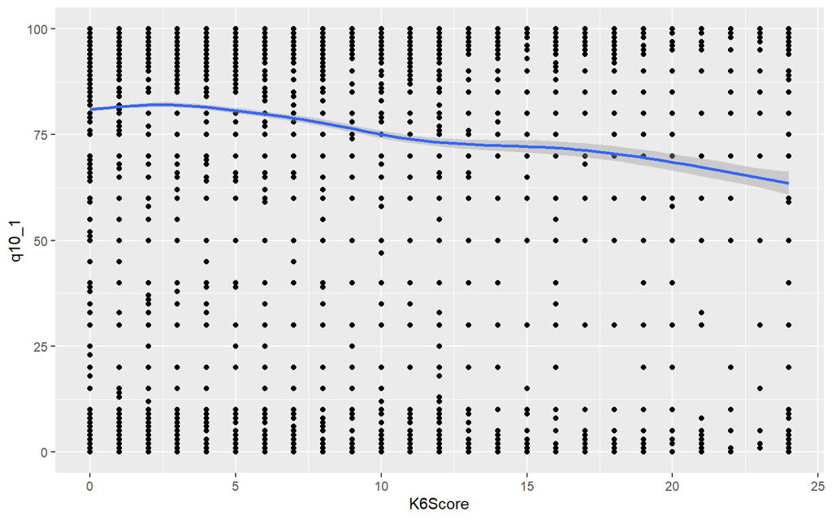

```r
#install.packages("ggplot2") #グラフを作図する時に使うパッケージです
library(ggplot2)

p <- ggplot(data = vdata, mapping = aes(x = K6Score, y =q10_1))
p + geom_point() + geom_smooth()
```

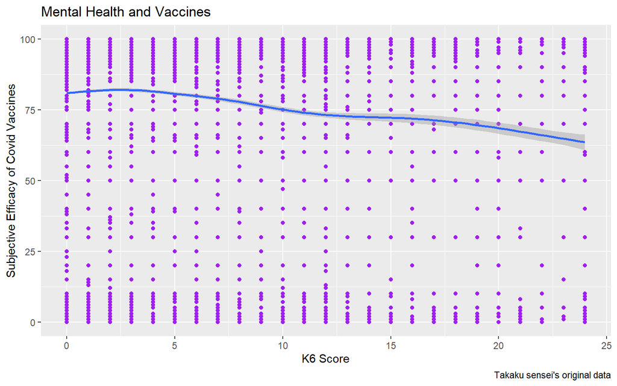

```r
#ラベルなどを着けて加工
p <- ggplot(data = vdata, mapping = aes(x = K6Score, y =q10_1))
p + geom_point(color="purple") + geom_smooth() +
  labs(x = "K6 Score", y = "Subjective Efficacy of Covid Vaccines",
       title = "Mental Health and Vaccines", caption = "Takaku sensei's original data")
```

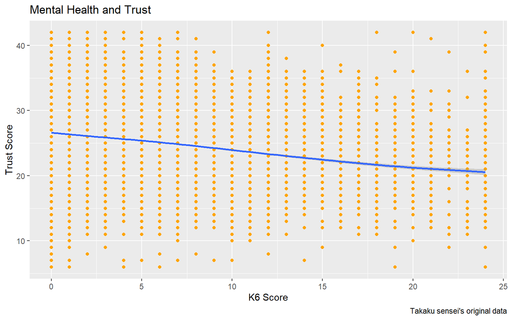

```r
p <- ggplot(data = vdata, mapping = aes(x = K6Score, y =TrustScore))
p + geom_point(color="orange") + geom_smooth()+
  labs(x = "K6 Score", y = "Trust Score",
       title = "Mental Health and Trust", caption = "Takaku sensei's original data")
```

作成した図表を保存してみましょう。図の保存はggsaveというコマンドで以下のように行うことができます。

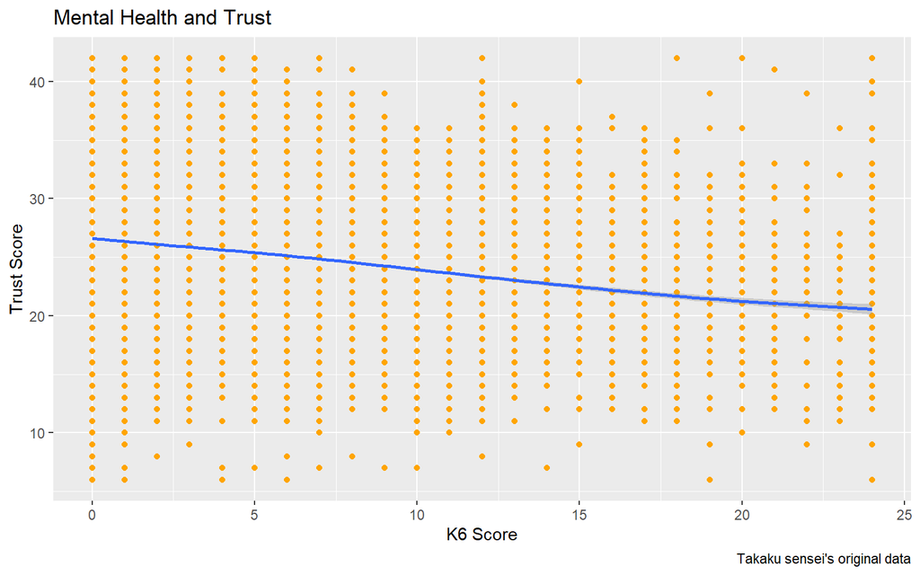

```r
library(ggplot2)
library(tidyverse)

p <- ggplot(data = vdata, mapping = aes(x = K6Score, y =TrustScore))
p + geom_point(color="orange") + geom_smooth()+
  labs(x = "K6 Score", y = "Trust Score",
       title = "Mental Health and Trust", caption = "Takaku sensei's original data")
```

```r
#setwdの場所に保存する場合
#ggsave(filename = "my_figure.pdf")

#指定したフォルダの下にfigureというフォルダがあってそこに保存したい場合にはhereというパッケージをインストールして使うと便利
#install.packages("here", repos = "https://cran.r-project.org/")
library(here)
ggsave(here("figure", "my_figure.pdf"))
```

# 棒グラフとヒストグラム

K6スコアの分布を棒グラフとヒストグラムで書いてみよう。二つのグラフはggplotの箇所は全く同じで、プロットタイプを指定するgeom_以下が変るだけ。

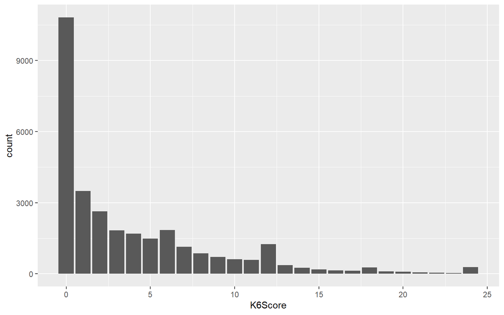

```r
#棒グラフ
p <- ggplot(data = vdata, mapping = aes(x = K6Score))
p + geom_bar()
```

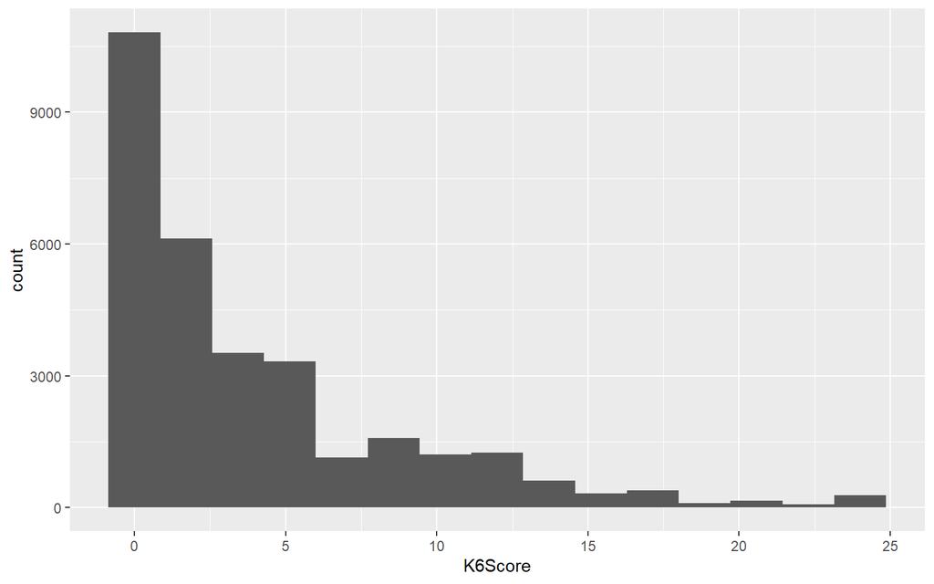

```r
#ヒストグラム
p <- ggplot(data = vdata, mapping = aes(x = K6Score))
p + geom_histogram(bins = 15)
```

```r
#binの数を15に指定。指定しなくても良い
```

棒グラフで男女の内訳がわかるように記載してみよう。この時、Femは現在女性ならば１、男性ならば０が格納されているが、このままではグラフを作成してくれない。文字列に変換してから作図すると上手く作成できる。

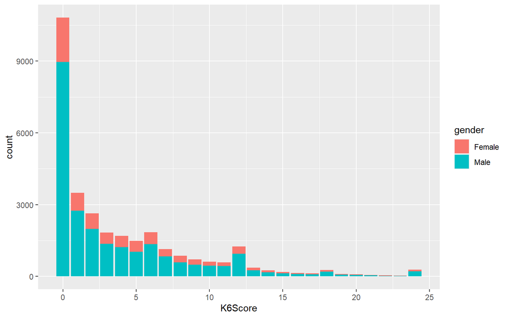

```r
vdata <- vdata %>% mutate(gender = ifelse(Fem == 1, "Female", "Male"))

p <- ggplot(data = vdata, mapping = aes(x = K6Score, fill = gender))
p + geom_bar()
```

データセットによっては初めからgenderのように文字列が記載されているものがある。データの型を確認する際にはstr(df)と入力する。今試みにstr(vdata$変数名)と入力すると以下が出力される。

```r
str(vdata$sc1_1)
```

```
##  int [1:30892] 1 1 1 1 1 1 1 1 1 1 ...
```

```r
str(vdata$TrustScore)
```

```
##  num [1:30892] 20 17 19 20 24 26 25 37 23 23 ...
```

```r
str(vdata$gender)
```

```
##  chr [1:30892] "Male" "Male" "Male" "Male" "Male" "Female" "Female" "Male" ...
```

intと書かれているのが型です。

これは整数(integer)を表します。

int: integer, 整数

dbl: double, 実数

num: numeric, 数値

chr: character, 文字列

genderは文字列として認識されています。文字列として認識されている変数を数値に直す必要がある場合もあります。その場合にはas_factor()を用いることで、数値解析に用いることができます。

```r
vdata <- vdata %>% mutate(gender_factor = as_factor(gender))

vdata$gender_factor %>% table()
```

```
## .
##   Male Female
##  23793   7099
```

```r
str(vdata$gender_factor)
```

```
##  Factor w/ 2 levels "Male","Female": 1 1 1 1 1 2 2 1 1 1 ...
```

```r
vdata$Fem %>% table()
```

```
## .
##     0     1
## 23793  7099
```

```r
str(vdata$Fem)
```

```
##  num [1:30892] 0 0 0 0 0 1 1 0 0 0 ...
```

# カーネル密度プロット

ヒストグラムと並んでよく用いられる変数分布の可視化の方法としてkernel density plotがあります。geom_以下が変るだけです。

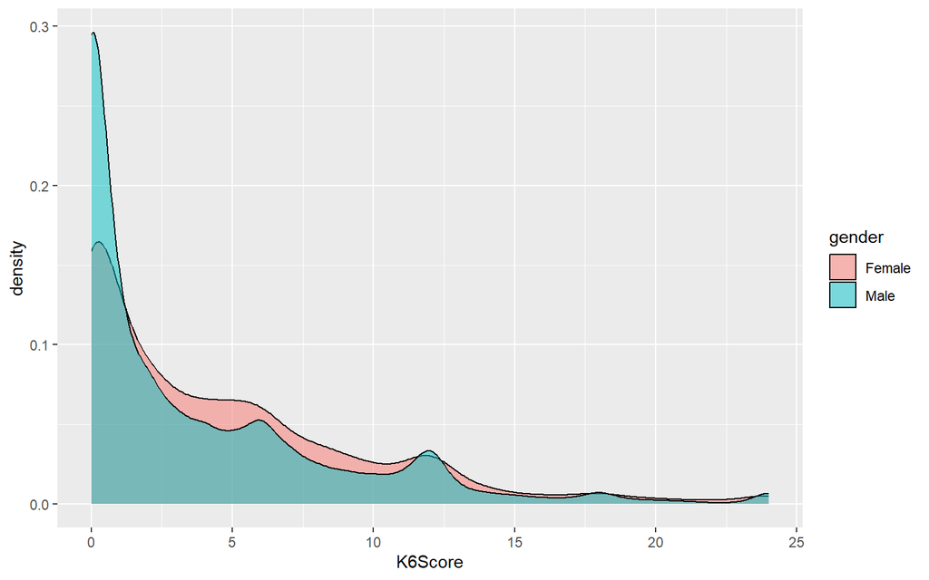

```r
p <- ggplot(data = vdata, mapping = aes(x = K6Score, fill = gender))
p + geom_density(alpha = 0.5)
```

```r
#alphaは透明度の設定です。
```

みると、男性のほうがk6がゼロ近傍（メンタルは絶好調）の人が多いことが一発で分かりますね。

★練習問題

・ワクチンの効果に関する男女の回答の違いをkernel density plotを用いて可視化してください

・大卒かどうかでワクチンの効果に関する回答の違いをkernel density plotを用いて可視化してください

# 折れ線グラフ

生まれ年別にワクチンを2回接種した人の割合を折れ線グラフでプロットしてみよう。折れ線グラフの場合には、集計（e.g., 2回接種した人の割合の計算）が必要になることが多いので、集計した結果を別のデータフレームに保存してから結果をプロットすると作図出来ます。

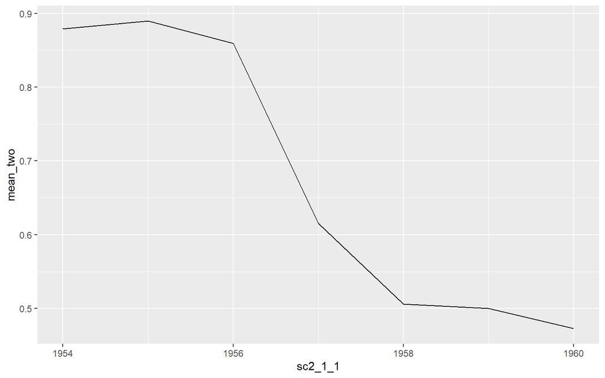

```r
#まず群別に集計してから結果をvdata.lineに保存する
vdata.line <- vdata %>% group_by(sc2_1_1) %>% summarize(mean_two = mean(TwoDose,na.rm = TRUE))

#vdata.lineを呼び出して折れ線グラフを作成
p <- ggplot(data = vdata.line, mapping = aes(x = sc2_1_1, y = mean_two))
p + geom_line()
```

1957年以降に生まれた人がワクチンの2回接種を終えている確率は1956年生まれ以前のコホートよりも大幅に低下します。これは、ワクチンの受診勧奨が65歳以上という年齢を基準に決まっていたためです。

# 群別のグラフ

ワクチンの2回接種が終わっているかどうか（生年別）について、学歴別、男女別で合計4つのグラフを一気に作図してみよう。一つの変数（e.g., 学歴別のみ）でプロットする場合にはfacet_wrap()を用いるが、二つの場合にはfacet_grid(1つ目の層 ~ 2つ目の層)を用いて以下のように書く。

```r
#生年、学歴、性で層別
vdata.line <- vdata %>% group_by(sc2_1_1,Edu,gender) %>% summarize(mean_two = mean(TwoDose,na.rm = TRUE))
```

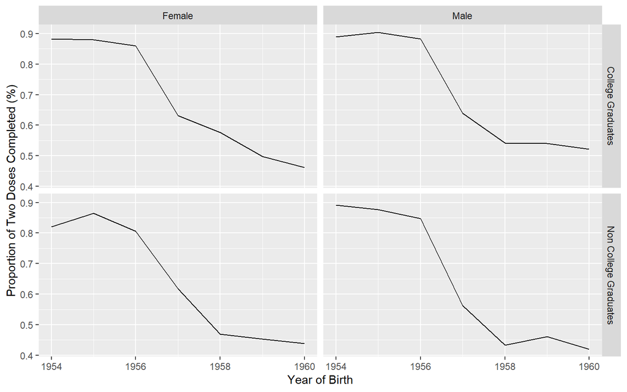

```r
#vdata.lineを呼び出して折れ線グラフを作成
p <- ggplot(data = vdata.line, mapping = aes(x = sc2_1_1, y = mean_two))
p + geom_line() + facet_grid(Edu ~ gender) + labs(x = "Year of Birth", y = "Proportion of Two Doses Completed (%)")
```

# 箱ひげ図

変数の分布を群間で比べる方法として箱ひげ図も有用です。大卒と非大卒でワクチンの有効性評価に違いがあるのか箱ひげ図で確認してみましょう。描画はgeom_boxplot()を用います。

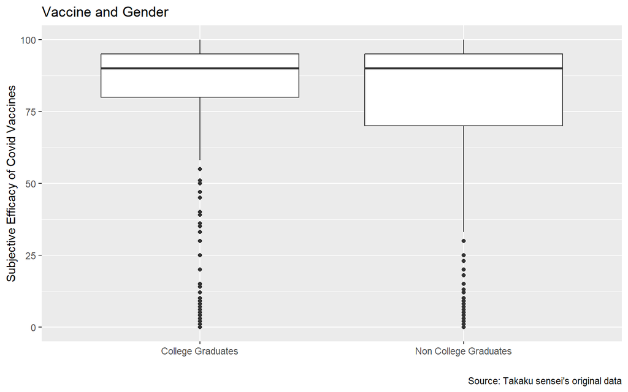

```r
p <- ggplot(data = vdata, mapping = aes(y = q10_1, x = Edu))
p + geom_boxplot() + labs(x = "", y = "Subjective Efficacy of Covid Vaccines",
       title = "Vaccine and Gender", caption = "Source: Takaku sensei's original data")
```

次に地域別に比較してみましょう。sc4は都道府県です。

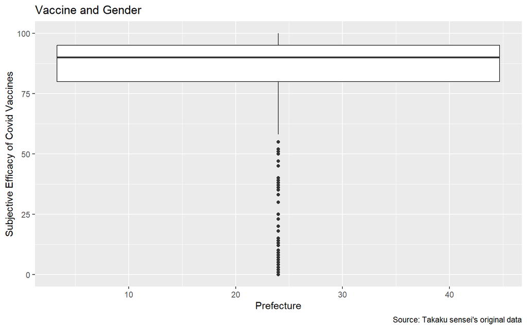

```r
p <- ggplot(data = vdata, mapping = aes(y = q10_1, x = sc4))
p + geom_boxplot() + labs(x = "Prefecture", y = "Subjective Efficacy of Covid Vaccines",
       title = "Vaccine and Gender", caption = "Source: Takaku sensei's original data")
```

あれれ、うまく作図できませんね・・・。これはsc4が「整数(integer)」だからです。

```r
#sc4の型を確認
str(vdata$sc4)
```

```
##  int [1:30892] 4 8 23 23 12 23 12 13 34 28 ...
```

そこで、適宜case_whenを用いて「都道府県名」を記述する変数を作成します。

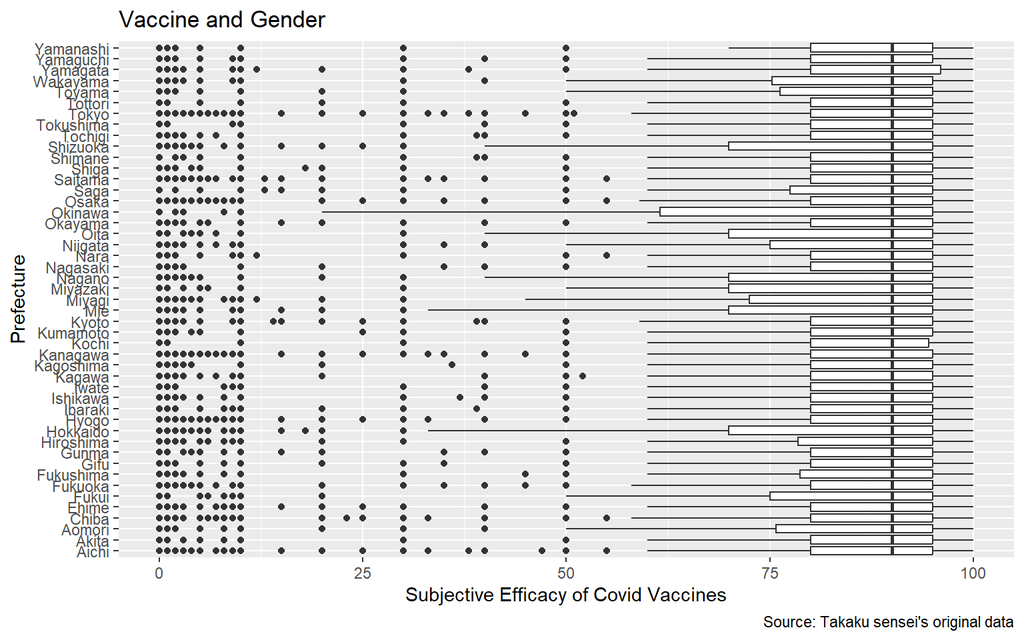

```r
vdata <- vdata %>% mutate(pref_name = case_when(sc4 == 1 ~ "Hokkaido",
                                                  sc4 ==2 ~ "Aomori",
                                                  sc4 ==3 ~ "Iwate",
                                                  sc4 ==4 ~ "Miyagi",
                                                  sc4 ==5 ~ "Akita",
                                                  sc4 ==6 ~ "Yamagata",
                                                  sc4 ==7 ~ "Fukushima",
                                                  sc4 ==8 ~ "Ibaraki",
                                                  sc4 ==9 ~ "Tochigi",
                                                  sc4 ==10 ~ "Gunma",
                                                  sc4 ==11 ~ "Saitama",
                                                  sc4 ==12 ~ "Chiba",
                                                  sc4 ==13 ~ "Tokyo",
                                                  sc4 ==14 ~ "Kanagawa",
                                                  sc4 ==15 ~ "Niigata",
                                                  sc4 ==16 ~ "Toyama",
                                                  sc4 ==17 ~ "Ishikawa",
                                                  sc4 ==18 ~ "Fukui",
                                                  sc4 ==19 ~ "Yamanashi",
                                                  sc4 ==20 ~ "Nagano",
                                                  sc4 ==21 ~ "Gifu",
                                                  sc4 ==22 ~ "Shizuoka",
                                                  sc4 ==23 ~ "Aichi",
                                                  sc4 ==24 ~ "Mie",
                                                  sc4 ==25 ~ "Shiga",
                                                  sc4 ==26 ~ "Kyoto",
                                                  sc4 ==27 ~ "Osaka",
                                                  sc4 ==28 ~ "Hyogo",
                                                  sc4 ==29 ~ "Nara",
                                                  sc4 ==30 ~ "Wakayama",
                                                  sc4 ==31 ~ "Tottori",
                                                  sc4 ==32 ~ "Shimane",
                                                  sc4 ==33 ~ "Okayama",
                                                  sc4 ==34 ~ "Hiroshima",
                                                  sc4 ==35 ~ "Yamaguchi",
                                                  sc4 ==36 ~ "Tokushima",
                                                  sc4 ==37 ~ "Kagawa",
                                                  sc4 ==38 ~ "Ehime",
                                                  sc4 ==39 ~ "Kochi",
                                                  sc4 ==40 ~ "Fukuoka",
                                                  sc4 ==41 ~ "Saga",
                                                  sc4 ==42 ~ "Nagasaki",
                                                  sc4 ==43 ~ "Kumamoto",
                                                  sc4 ==44 ~ "Oita",
                                                  sc4 ==45 ~ "Miyazaki",
                                                  sc4 ==46 ~ "Kagoshima",
                                                  sc4 ==47 ~ "Okinawa",
))


p <- ggplot(data = vdata, mapping = aes(y = q10_1, x = pref_name))
p + geom_boxplot() + coord_flip() + labs(x = "Prefecture", y = "Subjective Efficacy of Covid Vaccines",
       title = "Vaccine and Gender", caption = "Source: Takaku sensei's original data")
```

見にくいので、東北などの地域別にしましょうか。箱ひげ図と良く似ているものとしてバイオリンプロットがあります。これもgeom_violin()を用いて書くことができます。

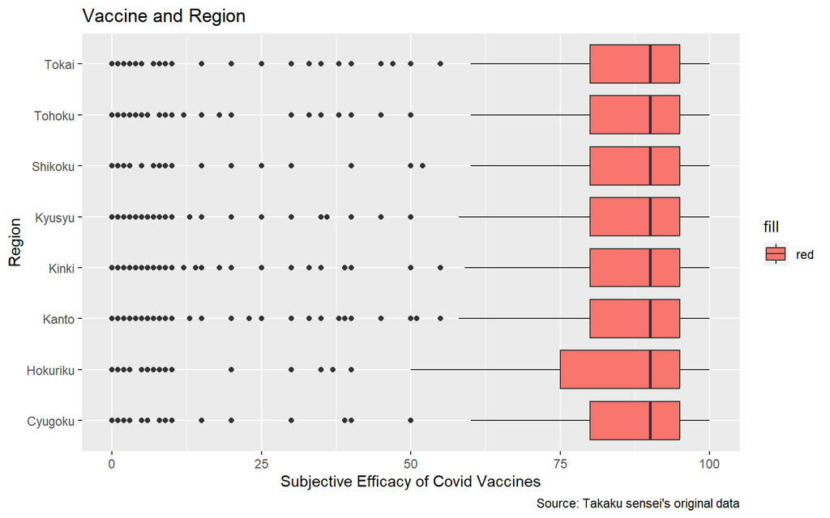

```r
vdata <- vdata %>% mutate(region_name = case_when(pref_name =="Hokkaido" ~ "Tohoku",
                                                  pref_name =="Aomori" ~ "Tohoku",
                                                  pref_name =="Iwate" ~ "Tohoku",
                                                  pref_name =="Miyagi" ~ "Tohoku",
                                                  pref_name =="Akita" ~ "Tohoku",
                                                  pref_name =="Yamagata" ~ "Tohoku",
                                                  pref_name =="Fukushima" ~ "Tohoku",
                                                  pref_name =="Ibaraki" ~ "Kanto",
                                                  pref_name =="Tochigi" ~ "Kanto",
                                                  pref_name =="Gunma" ~ "Kanto",
                                                  pref_name =="Saitama" ~ "Kanto",
                                                  pref_name =="Chiba" ~ "Kanto",
                                                  pref_name =="Tokyo" ~ "Kanto",
                                                  pref_name =="Kanagawa" ~ "Kanto",
                                                  pref_name =="Niigata" ~ "Hokuriku",
                                                  pref_name =="Toyama" ~ "Hokuriku",
                                                  pref_name =="Ishikawa" ~ "Hokuriku",
                                                  pref_name =="Fukui" ~ "Hokuriku",
                                                  pref_name =="Yamanashi" ~ "Tokai",
                                                  pref_name =="Nagano" ~ "Tokai",
                                                  pref_name =="Gifu" ~ "Tokai",
                                                  pref_name =="Shizuoka" ~ "Tokai",
                                                  pref_name =="Aichi" ~ "Tokai",
                                                  pref_name =="Mie" ~ "Kinki",
                                                  pref_name =="Shiga" ~ "Kinki",
                                                  pref_name =="Kyoto" ~ "Kinki",
                                                  pref_name =="Osaka" ~ "Kinki",
                                                  pref_name =="Hyogo" ~ "Kinki",
                                                  pref_name =="Nara" ~ "Kinki",
                                                  pref_name =="Wakayama" ~ "Kinki",
                                                  pref_name =="Tottori" ~ "Cyugoku",
                                                  pref_name =="Shimane" ~ "Cyugoku",
                                                  pref_name =="Okayama" ~ "Cyugoku",
                                                  pref_name =="Hiroshima" ~ "Cyugoku",
                                                  pref_name =="Yamaguchi" ~ "Cyugoku",
                                                  pref_name =="Tokushima" ~ "Shikoku",
                                                  pref_name =="Kagawa" ~ "Shikoku",
                                                  pref_name =="Ehime" ~ "Shikoku",
                                                  pref_name =="Kochi" ~ "Shikoku",
                                                  pref_name =="Fukuoka" ~ "Kyusyu",
                                                  pref_name =="Saga" ~ "Kyusyu",
                                                  pref_name =="Nagasaki" ~ "Kyusyu",
                                                  pref_name =="Kumamoto" ~ "Kyusyu",
                                                  pref_name =="Oita" ~ "Kyusyu",
                                                  pref_name =="Miyazaki" ~ "Kyusyu",
                                                  pref_name =="Kagoshima" ~ "Kyusyu",
                                                  pref_name =="Okinawa" ~ "Kyusyu"))

#箱ひげ図
p <- ggplot(data = vdata, mapping = aes(y = q10_1, x = region_name, fill="red"))
p + geom_boxplot() + coord_flip() + labs(x = "Region", y = "Subjective Efficacy of Covid Vaccines",
       title = "Vaccine and Region", caption = "Source: Takaku sensei's original data")
```

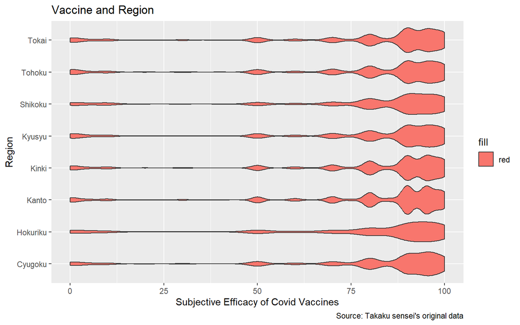

```r
#バイオリンプロット
p <- ggplot(data = vdata, mapping = aes(y = q10_1, x = region_name, fill="red"))
p + geom_violin() + coord_flip() + labs(x = "Region", y = "Subjective Efficacy of Covid Vaccines",
       title = "Vaccine and Region", caption = "Source: Takaku sensei's original data")
```

バイオリンプロットをみると、どの都道府県にもワクチンは全く効かないと考えている層（i.e., 反ワク）が一定数いることが分かります。

# 「月齢」の作成

日本のワクチン接種戦略は高齢者に対する優先接種を厳密に守った点で他の先進国と異なります。英米はワクチン確保が順調だったので、形式上優先接種の順番を決めていましたが、結局すぐに「みんなどんどん打とう」という政策になりました。それでは、高齢者とは一体誰でしょうか？これは行政的に厳格に決まっていて「2021年度中に65歳以上になる人」です。具体的には1957年4月1日より前に生まれていれば優先接種の対象となり、1957年4月2日生まれの人は対象になりませんでした。

そこで、生まれ月（sc2_1_2）の情報を用いて1957年3月生まれは0、2月生まれは1、逆に1957年4月生まれは-1、5月生まれは-2となるような変数を作成してみましょう。この変数はRegression Discontinuity Designの分析ではrunning variable と呼ばれるのでRvarという変数名にしましょう。

```r
vdata <- vdata %>% mutate(Rvar = case_when(sc2_1_1 ==1954 &  sc2_1_2 ==4 ~ 35,
                                             sc2_1_1 ==1954 &  sc2_1_2 ==5 ~ 34,
                                             sc2_1_1 ==1954 &  sc2_1_2 ==6 ~ 33,
                                             sc2_1_1 ==1954 &  sc2_1_2 ==7 ~ 32,
                                             sc2_1_1 ==1954 &  sc2_1_2 ==8 ~ 31,
                                             sc2_1_1 ==1954 &  sc2_1_2 ==9 ~ 30,
                                             sc2_1_1 ==1954 &  sc2_1_2 ==10 ~ 29,
                                             sc2_1_1 ==1954 &  sc2_1_2 ==11 ~ 28,
                                             sc2_1_1 ==1954 &  sc2_1_2 ==12 ~ 27,
                                             sc2_1_1 ==1955 &  sc2_1_2 ==1 ~ 26,
                                             sc2_1_1 ==1955 &  sc2_1_2 ==2 ~ 25,
                                             sc2_1_1 ==1955 &  sc2_1_2 ==3 ~ 24,
                                             sc2_1_1 ==1955 &  sc2_1_2 ==4 ~ 23,
                                             sc2_1_1 ==1955 &  sc2_1_2 ==5 ~ 22,
                                             sc2_1_1 ==1955 &  sc2_1_2 ==6 ~ 21,
                                             sc2_1_1 ==1955 &  sc2_1_2 ==7 ~ 20,
                                             sc2_1_1 ==1955 &  sc2_1_2 ==8 ~ 19,
                                             sc2_1_1 ==1955 &  sc2_1_2 ==9 ~ 18,
                                             sc2_1_1 ==1955 &  sc2_1_2 ==10 ~ 17,
                                             sc2_1_1 ==1955 &  sc2_1_2 ==11 ~ 16,
                                             sc2_1_1 ==1955 &  sc2_1_2 ==12 ~ 15,
                                             sc2_1_1 ==1956 &  sc2_1_2 ==1 ~ 14,
                                             sc2_1_1 ==1956 &  sc2_1_2 ==2 ~ 13,
                                             sc2_1_1 ==1956 &  sc2_1_2 ==3 ~ 12,
                                             sc2_1_1 ==1956 &  sc2_1_2 ==4 ~ 11,
                                             sc2_1_1 ==1956 &  sc2_1_2 ==5 ~ 10,
                                             sc2_1_1 ==1956 &  sc2_1_2 ==6 ~ 9,
                                             sc2_1_1 ==1956 &  sc2_1_2 ==7 ~ 8,
                                             sc2_1_1 ==1956 &  sc2_1_2 ==8 ~ 7,
                                             sc2_1_1 ==1956 &  sc2_1_2 ==9 ~ 6,
                                             sc2_1_1 ==1956 &  sc2_1_2 ==10 ~ 5,
                                             sc2_1_1 ==1956 &  sc2_1_2 ==11 ~ 4,
                                             sc2_1_1 ==1956 &  sc2_1_2 ==12 ~ 3,
                                             sc2_1_1 ==1957 &  sc2_1_2 ==1 ~ 2,
                                             sc2_1_1 ==1957 &  sc2_1_2 ==2 ~ 1,
                                             sc2_1_1 ==1957 &  sc2_1_2 ==3 ~ 0,
                                             sc2_1_1 ==1957 &  sc2_1_2 ==4 ~ -1,
                                             sc2_1_1 ==1957 &  sc2_1_2 ==5 ~ -2,
                                             sc2_1_1 ==1957 &  sc2_1_2 ==6 ~ -3,
                                             sc2_1_1 ==1957 &  sc2_1_2 ==7 ~ -4,
                                             sc2_1_1 ==1957 &  sc2_1_2 ==8 ~ -5,
                                             sc2_1_1 ==1957 &  sc2_1_2 ==9 ~ -6,
                                             sc2_1_1 ==1957 &  sc2_1_2 ==10 ~ -7,
                                             sc2_1_1 ==1957 &  sc2_1_2 ==11 ~ -8,
                                             sc2_1_1 ==1957 &  sc2_1_2 ==12 ~ -9,
                                             sc2_1_1 ==1958 &  sc2_1_2 ==1 ~ -10,
                                             sc2_1_1 ==1958 &  sc2_1_2 ==2 ~ -11,
                                             sc2_1_1 ==1958 &  sc2_1_2 ==3 ~ -12,
                                             sc2_1_1 ==1958 &  sc2_1_2 ==4 ~ -13,
                                             sc2_1_1 ==1958 &  sc2_1_2 ==5 ~ -14,
                                             sc2_1_1 ==1958 &  sc2_1_2 ==6 ~ -15,
                                             sc2_1_1 ==1958 &  sc2_1_2 ==7 ~ -16,
                                             sc2_1_1 ==1958 &  sc2_1_2 ==8 ~ -17,
                                             sc2_1_1 ==1958 &  sc2_1_2 ==9 ~ -18,
                                             sc2_1_1 ==1958 &  sc2_1_2 ==10 ~ -19,
                                             sc2_1_1 ==1958 &  sc2_1_2 ==11 ~ -20,
                                             sc2_1_1 ==1958 &  sc2_1_2 ==12 ~ -21,
                                             sc2_1_1 ==1959 &  sc2_1_2 ==1 ~ -22,
                                             sc2_1_1 ==1959 &  sc2_1_2 ==2 ~ -23,
                                             sc2_1_1 ==1959 &  sc2_1_2 ==3 ~ -24,
                                             sc2_1_1 ==1959 &  sc2_1_2 ==4 ~ -25,
                                             sc2_1_1 ==1959 &  sc2_1_2 ==5 ~ -26,
                                             sc2_1_1 ==1959 &  sc2_1_2 ==6 ~ -27,
                                             sc2_1_1 ==1959 &  sc2_1_2 ==7 ~ -28,
                                             sc2_1_1 ==1959 &  sc2_1_2 ==8 ~ -29,
                                             sc2_1_1 ==1959 &  sc2_1_2 ==9 ~ -30,
                                             sc2_1_1 ==1959 &  sc2_1_2 ==10 ~ -31,
                                             sc2_1_1 ==1959 &  sc2_1_2 ==11 ~ -32,
                                             sc2_1_1 ==1959 &  sc2_1_2 ==12 ~ -33,
                                             sc2_1_1 ==1960 &  sc2_1_2 ==1 ~ -34,
                                             sc2_1_1 ==1960 &  sc2_1_2 ==2 ~ -35,
                                             sc2_1_1 ==1960 &  sc2_1_2 ==3 ~ -36,
))
```

ワクチンの接種率が月齢で変るのかプロットしてみましょう。ここでも、月齢ごとの接種率の平均を算出して別のデータフレームに保存した上で、ggplotを用いて作図します。

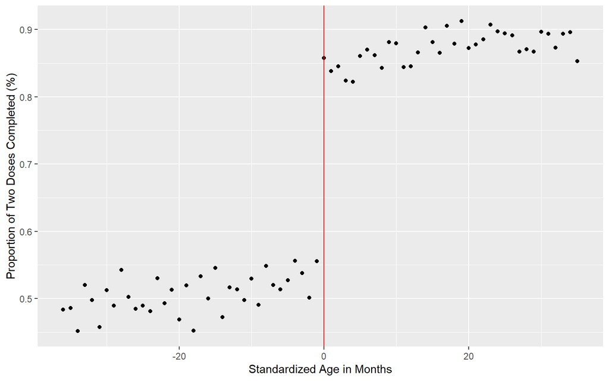

```r
vdata.two <- vdata %>% group_by(Rvar) %>% summarize(mean_two = mean(TwoDose,na.rm = TRUE))

p <- ggplot(data = vdata.two, mapping = aes(x = Rvar, y = mean_two))
p + geom_point() + labs(x = "Standardized Age in Months", y = "Proportion of Two Doses Completed (%)")+ geom_vline(xintercept = 0,colour = "red", )
```

★例１

q18_1は「新型コロナウイルスがとても怖い」かどうかを5段階の質問項目で尋ねています。x軸を月齢、y軸をこの質問に対する回答として、ワクチン接種率が上昇するタイミングで新型コロナウイルスに対する認識に変化があるか可視化してください。可能であればy軸のレンジは3から5に設定してください(scale_y_continuousなどを使用) 。

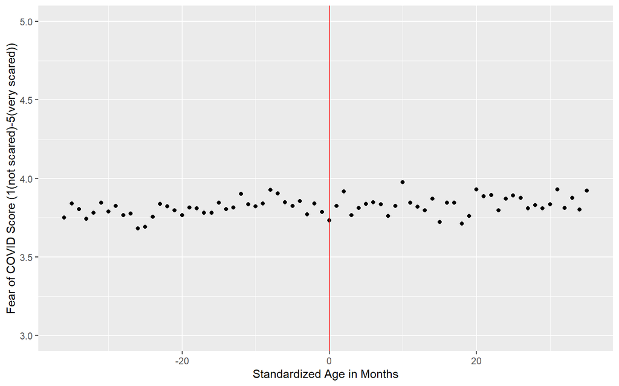

```r
vdata.fear <- vdata %>% group_by(Rvar) %>% summarize(mean_covid = mean(q18_1,na.rm = TRUE))

p <- ggplot(data = vdata.fear, mapping = aes(x = Rvar, y = mean_covid))
p + geom_point() + labs(x = "Standardized Age in Months", y = "Fear of COVID Score (1(not scared)-5(very scared))")+geom_vline(xintercept = 0,colour = "red", )+scale_y_continuous(limits = c(3, 5))
```

★例2

q22_4は「あなたが住んでいる自治体では、ワクチン接種は順調に進んでいる」かどうかを5段階の質問項目で尋ねています。x軸を月齢、y軸をこの質問に対する回答として、ワクチン接種率が上昇するタイミングでワクチンの接種状況に対する評価に変化があるか可視化してください。

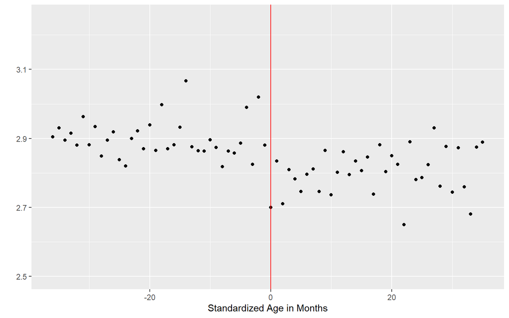

```r
vdata.prog <- vdata %>% group_by(Rvar) %>% summarize(mean_prog = mean(q22_2_4,na.rm = TRUE))

p <- ggplot(data = vdata.prog, mapping = aes(x = Rvar, y = mean_prog))
p + geom_point() + labs(x = "Standardized Age in Months", y = "ワクチンの接種状況評価 (1(順調)-5(順調でない))")+geom_vline(xintercept = 0,colour = "red", )+scale_y_continuous(limits = c(2.5, 3.25))
```

★練習問題

任意の変数を1つ選んでワクチン接種率が上昇するRVar = 0 のポイントで変化が生じているか可視化してください。

# 変数の選択

インポートしたデータの中に不要な変数が含まれていたり、前処理の結果不要になった変数が出てくることはよくあります。 dplyrの関数select()を用いると、データフレームの変数を選択したり、削除したりすることができます。まずはvdataからFemとCollegeを抽出してみましょう。

```r
vdata_selected <- vdata %>% select(Fem, College)

head(vdata_selected)
```

```
##   Fem College
## 1   0       1
## 2   0       0
## 3   0       0
## 4   0       0
## 5   0       1
## 6   1       0
```

2つの変数のみのデータフレームになりました。ハイフン-を使うと、該当する変数を削除し、残りの変数はそのままとすることができます。

```r
vdata_selected <- vdata %>% select(-Fem, -College)
```

# 記述統計表の作成

論文作成時には、使用した変数の概要をまとめた記述統計表を作成してください。データセットには大抵、数多くの変数が入っているので、必要な変数のみ取り出して別のデータフレームに保存してから記述統計を出力すると良いです。具体的には、vdataからFem、College、SCollege、Rvar、Twodose、MIncome、q10_1を取り出して記述統計表を作成しましょう。ここでは、summarytoolsパッケージを用いた方法を紹介します。まずはパッケージを準備しておきましょう。

```r
#install.packages("summarytools")
library(summarytools)
```

パッケージをインストールしたら以下のようにsummarytoolsのdescr()を用います。

```r
vdata_selected <- vdata %>% select(Fem,College,SCollege,Rvar,TwoDose,MIncome,q10_1)

vdata_selected %>% descr()
```

```
## Descriptive Statistics
## vdata_selected
## N: 30892
##
##                      College        Fem    MIncome      q10_1       Rvar   SCollege    TwoDose
## ----------------- ---------- ---------- ---------- ---------- ---------- ---------- ----------
##              Mean       0.57       0.23       0.37      79.62      -3.26       0.32       0.67
##           Std.Dev       0.50       0.42       0.48      26.35      20.69       0.47       0.47
##               Min       0.00       0.00       0.00       0.00     -36.00       0.00       0.00
##                Q1       0.00       0.00       0.00      80.00     -22.00       0.00       0.00
##            Median       1.00       0.00       0.00      90.00      -5.00       0.00       1.00
##                Q3       1.00       0.00       1.00      95.00      14.00       1.00       1.00
##               Max       1.00       1.00       1.00     100.00      35.00       1.00       1.00
##               MAD       0.00       0.00       0.00      11.86      26.69       0.00       0.00
##               IQR       1.00       0.00       1.00      15.00      36.00       1.00       1.00
##                CV       0.87       1.83       1.30       0.33      -6.35       1.45       0.70
##          Skewness      -0.28       1.28       0.54      -1.96       0.14       0.76      -0.72
##       SE.Skewness       0.01       0.01       0.02       0.01       0.01       0.01       0.01
##          Kurtosis      -1.92      -0.35      -1.71       2.87      -1.19      -1.43      -1.48
##           N.Valid   30892.00   30892.00   24423.00   30892.00   30892.00   30892.00   30767.00
##         Pct.Valid     100.00     100.00      79.06     100.00     100.00     100.00      99.60
```

この表は情報量が多く見づらいので、オプションを加えて編集していきましょう。

1. stats: 平均mean・標準偏差sd・最小値min・最大値max・観測値n.validを表示させます
2. transpose: TRUEにして行列を入れ替えます
3. heading: オプションをFALSEにしてヘッダーを消します

```r
vdata_selected %>% descr(stats = c("mean", "sd", "min", "max", "n.valid"), transpose = TRUE, headings = FALSE)
```

```
##
##                   Mean   Std.Dev      Min      Max    N.Valid
## -------------- ------- --------- -------- -------- ----------
##        College    0.57      0.50     0.00     1.00   30892.00
##            Fem    0.23      0.42     0.00     1.00   30892.00
##        MIncome    0.37      0.48     0.00     1.00   24423.00
##          q10_1   79.62     26.35     0.00   100.00   30892.00
##           Rvar   -3.26     20.69   -36.00    35.00   30892.00
##       SCollege    0.32      0.47     0.00     1.00   30892.00
##        TwoDose    0.67      0.47     0.00     1.00   30767.00
```

この表をエクセルに張り付けて適宜修正すると、論文で使える記述統計表が作成できます。